# Marjum 2026-07 — v0001 Geometry Snapshot Review

**Milestone:** captured, reviewable snapshot of the current fit state, built on `v0001_marjum_geometry` (marjum-2026-07 @ `ba52532`), per Aaron's review-gate ruling on B2 (routed via experimental-strategist, 2026-09-13).

**Question.** Given the v0001 release and Aaron's three B2 rulings, what is the single reviewable statement of current transmitter/antenna position, uncertainty, and open items — before any further optimization proceeds?

**Aaron's rulings baked into this snapshot:**

1. Cite the transmitter's **±1.5 m** bracket as the defensible value now (hard bracket from independent-pair cross-checks, not a training residual).
2. **Log** the vertical-group disagreement as an open item; do not spend more optimizer time on it now — it is smaller (~1 m / 94 m, ~0.6°) than the ~0.9° Tx-direction uncertainty already carried to beam-analyst.
3. **Bracket the antenna position** like the transmitter, not a bare point estimate — an unbracketed antenna position feeding a beam fit is the "not a result" pattern the charter warns against.

**Constraint.** This captures current state only. No new optimizer fits or further convergence attempts were run to produce it; the antenna bracket below is a deterministic envelope/LOO computation over already-computed fits (`marjum_antenna_uncertainty.py`), exactly mirroring how the transmitter's bracket was built (`marjum_tx_uncertainty.py`).

```python
import json
from pathlib import Path

import numpy as np
import matplotlib.pyplot as plt

WORKSPACE = Path('/home/aparsons/projects/eigsep/terrain')
SNAP = WORKSPACE / 'v0001_marjum_geometry_snapshot'

manifest = json.loads((SNAP / 'manifest.json').read_text())
shared = json.loads((SNAP / 'shared.json').read_text())
tx = json.loads((SNAP / 'transmitter_position.json').read_text())
ant = json.loads((WORKSPACE / 'antenna_position_bracket.json').read_text())
cameras = [json.loads(l) for l in (SNAP / 'cameras.jsonl').read_text().splitlines() if l.strip()]

print('release:', manifest['release_id'], ' generated_utc:', manifest['generated_utc'])
print('source commit (marjum-2026-07):', 'ba52532 (v0001_marjum_geometry publish)')
print('coverage:', manifest['coverage'])
```

```
release: v0001_marjum_geometry  generated_utc: 2026-09-13T22:16:57Z
source commit (marjum-2026-07): ba52532 (v0001_marjum_geometry publish)
coverage: {'excluded_camera_poses': 8, 'labeled_images': 37, 'usable_camera_poses': 29}
```

## 1. Inputs & provenance

The antenna bracket is new: `antenna_position_bracket.json`, produced by `marjum_antenna_uncertainty.py` in this repo, consuming only pre-existing `.npz`/`report.json` outputs (no new fits).

```python
print('=== v0001_marjum_geometry manifest ===')
print('status:', manifest['status'], ' supersedes:', manifest['supersedes'])
print('release artifacts (recorded sha256[:16]):')
for name, info in manifest['release_artifacts'].items():
    print(f"  {name:20s} {info['sha256'][:16]}")

print()
print('=== antenna_position_bracket.json provenance ===')
prov = ant['provenance']
print('generator:', prov['generator'], '@', prov['generator_commit'])
print('generated_utc:', prov['generated_utc'])
print('inputs:')
for i in prov['inputs']:
    print(f"  {i['path']:55s} {i['sha256'][:16]}")
```

```
=== v0001_marjum_geometry manifest ===
status: candidate  supersedes: None
release artifacts (recorded sha256[:16]):
  cameras.jsonl        2ed744f833f689e9
  labels.json          4657c42e494d3b56
  shared.json          234c1d5ab7142318

=== antenna_position_bracket.json provenance ===
generator: terrain/marjum_antenna_uncertainty.py @ 986e8cf
generated_utc: 2026-09-13T23:43:10Z
inputs:
  terrain/cv_position_absolute/baseline.npz               fd7163b974de99f3
  terrain/cv_position_absolute/orientations.npz           0b835d234498ac13
  terrain/cv_position_absolute/positions.npz              5ee3c01d2a7e4fdb
  terrain/cv_position_absolute/poses.npz                  bdb00e55dbaf85fd
  terrain/cv_position_absolute/focal.npz                  88271ca83a5833d6
  terrain/cv_antenna_repick_v1/fit_antenna.npz            f76d6ee58374e258
  terrain/cv_position_absolute/alternative.npz            227de81e10a53d2d
  terrain/cv_antenna_repick_v1/report.json                49998213041bf4e1
```

## 2. Coverage — cameras and labels

`manifest.json`: **37** labeled images, **29** usable camera poses, **8** excluded pose attempts. `cameras.jsonl` tags each row with `pose_status` (usable/excluded), `fit_provenance` (established fixed camera vs. jointly fit against the transmitter ray), and `transmitter_conditioned` (True for the six cameras whose ray misses are circular evidence, per the transmitter caveats below).

```python
from collections import Counter

status_counts = Counter(c['pose_status'] for c in cameras)
prov_counts = Counter(c.get('fit_provenance') for c in cameras)
conditioned_counts = Counter(c.get('transmitter_conditioned') for c in cameras)
excluded = [c['image'] for c in cameras if c['pose_status'] != 'usable']

print('pose_status:', dict(status_counts))
print('fit_provenance:', dict(prov_counts))
print('transmitter_conditioned:', dict(conditioned_counts))
print('excluded images:', excluded)
```

```
pose_status: {'usable': 29, 'excluded': 8}
fit_provenance: {'joint terrain/features/transmitter fit': 6, 'established fixed camera': 23, None: 8}
transmitter_conditioned: {True: 6, False: 31}
excluded images: ['IMG_2219.HEIC', 'IMG_2225.HEIC', 'IMG_2227.HEIC', 'IMG_2228.HEIC', 'IMG_2230.HEIC', 'IMG_2241.HEIC', 'IMG_2242.HEIC', 'IMG_2243.HEIC']
```

## 3. Transmitter position — recommended value and bracket

Unchanged from B2: `shared.json` / `transmitter_position.json` in this release. Per Aaron's ruling, **cite `recommended_for_propagation`**, not the `working_candidate` (which fails acceptance).

```python
rec = shared['transmitter']['recommended_for_propagation']
cand = shared['transmitter']['working_candidate']

print('recommended_for_propagation (CITE THIS):')
print('  position_enu_m:', rec['position_enu_m'])
print('  bound_m:', rec['bound_m'], '(', rec['bound_kind'], ')')
print('  stamp:', rec['stamp'])
print()
print('working_candidate (do not cite as final):')
print('  position_enu_m:', cand['position_enu_m'])
print('  accepted:', cand['accepted'], ' failing_checks:', cand['failing_checks'])
```

```
recommended_for_propagation (CITE THIS):
  position_enu_m: [1652.198, 2025.104, 1684.384]
  bound_m: 1.5 ( bounding radius, not a posterior sigma )
  stamp: marjum-2026-07/transmitter_position@v2+986e8cf

working_candidate (do not cite as final):
  position_enu_m: [1651.9749701444555, 2025.1048049047818, 1683.7038143160669]
  accepted: False  failing_checks: ['2211_transmitter_reprojection']
```

### 3a. Vertical-group disagreement — logged as OPEN ITEM (not pursued, per ruling 2)

The independent-pair cross-check (cameras 2210/2211, the only ones never conditioned on the transmitter ray) places the transmitter **~1.0 m higher** than the working candidate, with only ~0.46 m horizontal offset. Aaron's ruling: this is a smaller effect (~1 m over ~94 m antenna height, ≈0.6°) than the ~0.9° transmitter-direction uncertainty already carried downstream to beam-analyst — **log it, do not spend further optimizer time on it now**.

```python
ip = tx['independent_pair_solution']
print('independent-pair (2210+2211) solution (ENU):', ip['solution_enu_m'])
print('mutual ray gap:', ip['mutual_ray_gap_m'], 'm')
print('offset from recommended value (dE, dN, dU, horiz, total):', ip['offset_from_reference_m'])
print()
print('STATUS: OPEN ITEM, logged, not pursued further this milestone.')
print(ip['interpretation'])
```

```
independent-pair (2210+2211) solution (ENU): [1652.41, 2025.238, 1684.742]
mutual ray gap: 0.715 m
offset from recommended value (dE, dN, dU, horiz, total): {'dE': 0.435, 'dN': 0.133, 'dU': 1.038, 'horizontal': 0.455, 'total': 1.134}

STATUS: OPEN ITEM, logged, not pursued further this milestone.
The two unconditioned cameras agree with each other to 0.7 m and jointly place the transmitter ~1.0 m HIGHER than the v4 joint fit, with only ~0.45 m of horizontal offset. The disagreement is therefore almost purely vertical and is between two camera GROUPS, not a single bad pick.
```

## 4. Antenna position — now bracketed (ruling 3)

Previously a bare point estimate with `uncertainty: null` in `shared.json` (the legacy MCMC pilot was unconverged and supplied nothing usable). This notebook supplies a hard bracket built the same way as the transmitter's: envelope over independently-defensible fit generations, checked against the worst leave-one-out (LOO) held-out reprojection miss — the closest thing this fit has to independent evidence, since each LOO refit never sees the view it is then scored against.

```python
u = ant['uncertainty']
print('best_estimate_enu_m:', ant['best_estimate_enu_m'])
print('bound_m:', u['bound_m'], '(', u['kind'], ')')
print('methodological_envelope_m:', u['basis']['methodological_envelope_m'])
print('leave_one_out_max_ray_miss_m:', u['basis']['leave_one_out_max_ray_miss_m'],
      ' worst view:', u['basis']['leave_one_out_worst_view'])
print('rule:', u['basis']['rule'])
print()
print(u['interpretation'])
```

```
best_estimate_enu_m: [1655.868, 2030.923, 1777.397]
bound_m: 1.7 ( bounding radius, not a posterior sigma )
methodological_envelope_m: 0.658
leave_one_out_max_ray_miss_m: 1.641  worst view: 2210
rule: bound = ceil(max(envelope, loo_max_ray_miss) * 10) / 10

Treat as a hard bracket on the antenna position, built the same way as the transmitter's bracket. The generation envelope (incremental scale-up sequence + current repick) alone would give 0.658 m; the bound is instead set by the worst leave-one-out held-out reprojection miss (2210, 1.641 m), which i…
```

### 4a. Baseline diagnostics — generation envelope and LOO ray-miss by view

```python
gens = ant['generations']
hdr = f"{'generation':32s} {'E':>9s} {'N':>9s} {'U':>9s} {'outlier':>8s}"
print(hdr); print('-' * len(hdr))
for name, g in gens.items():
    p = g['antenna_enu_m']
    print(f"{name:32s} {p[0]:9.3f} {p[1]:9.3f} {p[2]:9.3f} {str(g['outlier_excluded_from_envelope']):>8s}")

print()
loo = ant['leave_one_out']
rm = loo['ray_miss_m']
hdr2 = f"{'image':8s} {'LOO ray_miss (m)':>17s} {'LOO position shift (m)':>24s}"
print(hdr2); print('-' * len(hdr2))
for k in sorted(rm, key=lambda k: -rm[k]):
    flag = '  <-- >1 m' if rm[k] > 1.0 else ''
    print(f"{k:8s} {rm[k]:17.3f} {loo['position_shift_from_best_m'][k]:24.3f}{flag}")
```

```
generation                               E         N         U  outlier
-----------------------------------------------------------------------
cv_position_absolute/baseline     1655.301  2030.311  1778.142    False
cv_position_absolute/orientations  1655.220  2030.611  1778.380    False
cv_position_absolute/positions    1655.357  2030.869  1778.536    False
cv_position_absolute/poses        1655.601  2030.915  1777.497    False
cv_position_absolute/focal        1655.646  2030.998  1777.452    False
cv_antenna_repick_v1              1655.868  2030.923  1777.397    False
cv_position_absolute/alternative  1643.589  2029.497  1781.677     True

image     LOO ray_miss (m)   LOO position shift (m)
---------------------------------------------------
2210                 1.641                    0.037  <-- >1 m
2209                 1.639                    0.043  <-- >1 m
2211                 1.584                    0.038  <-- >1 m
2232                 1.426                    0.010  <-- >1 m
2235                 1.364                    0.020  <-- >1 m
2217                 1.085                    0.048  <-- >1 m
2245                 0.634                    0.042
2214                 0.594                    0.065
2213                 0.498                    0.044
2238                 0.465                    0.027
2221                 0.426                    0.034
2215                 0.359                    0.063
2226                 0.358                    0.042
2231                 0.358                    0.039
2234                 0.281                    0.015
2223                 0.274                    0.043
2224                 0.273                    0.060
2239                 0.261                    0.034
2218                 0.241                    0.074
2222                 0.194                    0.031
2237                 0.183                    0.158
2220                 0.167                    0.038
2216                 0.106                    0.008
```

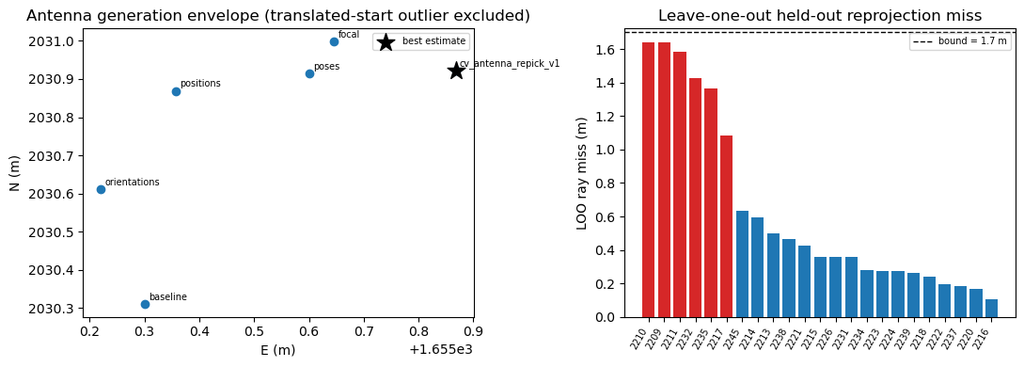

```python
fig, ax = plt.subplots(1, 2, figsize=(11, 4))

names = [n for n in gens if not gens[n]['outlier_excluded_from_envelope']]
E = [gens[n]['antenna_enu_m'][0] for n in names]
N = [gens[n]['antenna_enu_m'][1] for n in names]
ax[0].scatter(E, N, c='tab:blue')
for n, e, nn in zip(names, E, N):
    ax[0].annotate(n.split('/')[-1], (e, nn), fontsize=7, xytext=(3, 3), textcoords='offset points')
be = ant['best_estimate_enu_m']
ax[0].scatter([be[0]], [be[1]], marker='*', s=200, c='k', label='best estimate')
ax[0].set_xlabel('E (m)'); ax[0].set_ylabel('N (m)')
ax[0].set_title('Antenna generation envelope (translated-start outlier excluded)')
ax[0].legend(fontsize=7)

keys = sorted(rm, key=lambda k: -rm[k])
vals = [rm[k] for k in keys]
x = np.arange(len(keys))
ax[1].bar(x, vals, color=['tab:red' if v > 1.0 else 'tab:blue' for v in vals])
ax[1].axhline(u['bound_m'], color='k', ls='--', lw=1, label=f"bound = {u['bound_m']} m")
ax[1].set_xticks(x); ax[1].set_xticklabels(keys, rotation=60, ha='right', fontsize=7)
ax[1].set_ylabel('LOO ray miss (m)'); ax[1].set_title('Leave-one-out held-out reprojection miss')
ax[1].legend(fontsize=7)
fig.tight_layout()
fig.savefig('_geom_snapshot_ant_diag.png', dpi=140)
plt.show()
```

## 5. Terrain map — camera positions, transmitter, antenna

```
8 excluded views have no solved pose (camera: null) and are omitted from the map.
```

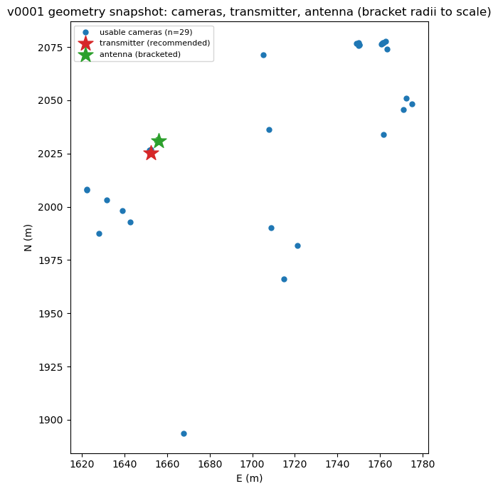

```python
fig, ax = plt.subplots(figsize=(8, 7))
usable = [c for c in cameras if c['pose_status'] == 'usable']
excl = [c for c in cameras if c['pose_status'] != 'usable']

ux = [c['camera']['position_enu_m'][0] for c in usable]
uy = [c['camera']['position_enu_m'][1] for c in usable]
ax.scatter(ux, uy, c='tab:blue', s=25, label=f'usable cameras (n={len(usable)})')

excl_with_pose = [c for c in excl if c.get('camera')]
if excl_with_pose:
    ex = [c['camera']['position_enu_m'][0] for c in excl_with_pose]
    ey = [c['camera']['position_enu_m'][1] for c in excl_with_pose]
    ax.scatter(ex, ey, c='tab:gray', s=25, marker='x',
               label=f'excluded pose attempts with a pose (n={len(excl_with_pose)})')
# Excluded views without a solved pose (camera: null) can't be plotted; they
# were rejected before or without ever producing camera coordinates.
print(f"{len(excl) - len(excl_with_pose)} excluded views have no solved pose "
      f"(camera: null) and are omitted from the map.")

tx_e, tx_n, _ = rec['position_enu_m']
ant_e, ant_n, _ = ant['best_estimate_enu_m']
ax.scatter([tx_e], [tx_n], c='tab:red', marker='*', s=250, label='transmitter (recommended)', zorder=5)
tx_circle = plt.Circle((tx_e, tx_n), rec['bound_m'], fill=False, color='tab:red', ls='--', lw=1)
ax.add_patch(tx_circle)
ax.scatter([ant_e], [ant_n], c='tab:green', marker='*', s=250, label='antenna (bracketed)', zorder=5)
ant_circle = plt.Circle((ant_e, ant_n), u['bound_m'], fill=False, color='tab:green', ls='--', lw=1)
ax.add_patch(ant_circle)

ax.set_xlabel('E (m)'); ax.set_ylabel('N (m)')
ax.set_title('v0001 geometry snapshot: cameras, transmitter, antenna (bracket radii to scale)')
ax.set_aspect('equal')
ax.legend(fontsize=8, loc='upper left')
fig.tight_layout()
fig.savefig('_geom_snapshot_map.png', dpi=140)
plt.show()
```

## 6. Per-image horizon fit quality — ray-traced overlays

Reuses the Fit Inspector's own machinery (`HorizonImage`, `marjum_camera.rays`, `Terrain`/`working_grid`-anchored DEM ray tracing): ray-traced sky/ground boundary (red) vs. the actual segmentation (green), at each image's pose, for **every camera behind this snapshot**.

**Which single file to load:** the summary sections above deliberately have no single fit file for the antenna (its bracket is an envelope over several generations, not one optimizer run). For this per-image visual check, however, one *does* exist: `cv_transmitter_joint_v4/fit_transmitter.npz` is the current working-candidate joint fit and already contains all **29** camera poses (23 established antenna cameras + 6 transmitter-conditioned) plus both the antenna and transmitter positions used above — its `antenna` field is verified below to be byte-identical to `cv_antenna_repick_v1`'s (the antenna bracket's best estimate), and `marjum_transmitter_accept.py` already checks the 23 established camera poses byte-for-byte against every prior generation. So this one file gives a self-consistent overlay set for both targets; only the antenna's *uncertainty bracket* comes from elsewhere. The transmitter position it carries is the **working candidate**, not the accepted product — every panel below is titled accordingly.

**Bug found and fixed while building this section:** `marjum_bundle.working_grid` (and a related sign-handling fix in `Terrain.skyline`) were missing from the checked-out `marjum_bundle.py`, even though other scripts in this repo (`_render_horizon_overlays.py`, `marjum_horizons.py`) import and depend on it, and a prior successful run's log (`_v4_vs_trial5_overlays.log`) shows it was present when that comparison was rendered. Restored verbatim from `/home/aparsons/projects/eigsep_old/terrain/marjum_bundle.py` (a known-good prior copy); its own submatrix-alignment self-check against `marjum_dem.npz` passed (`shift=(-1000.0, -1000.0)` for the `_sw` cache used below), and `test_marjum_bundle.py` still passes (5/7; the 2 failures are pre-existing `ModuleNotFoundError`s in `eigsep_terrain` unrelated to this fix). Without this restore, every ray in this section would have been traced against terrain read ~1.4 km off (1000 m in each of E and N), which would have made every overlay meaningless.

```python
import json as _json
import gc

import matplotlib.pyplot as plt
import numpy as np

try:
    import pillow_heif
    pillow_heif.register_heif_opener()
except Exception:
    pass

from eigsep_terrain.marjum_dem import MarjumDEM as _DEM
from eigsep_terrain.img import HorizonImage, PRM_ORDER
from marjum_bundle import working_grid
from marjum_camera import rays as camera_rays, project as camera_project

OVERLAY_FIT_FILE = 'cv_transmitter_joint_v4/fit_transmitter.npz'

dem = working_grid(_DEM(cache_file='marjum_dem_sw.npz'))
print('DEM working-grid shift:', dem._working_shift)
meta_all = _json.loads((WORKSPACE / 'meta.json').read_text())

with np.load(OVERLAY_FIT_FILE) as fit_npz:
    ov_keys = [str(k) for k in fit_npz['keys']]
    ov_cameras = np.asarray(fit_npz['cameras'], float)
    ov_distortion = np.asarray(fit_npz['distortion'], float)
    ov_antenna = np.asarray(fit_npz['antenna'], float)
    ov_transmitter = np.asarray(fit_npz['transmitter'], float)
    ov_shapes = np.asarray(fit_npz['shapes'], int)
    ov_conditioned = set(str(k) for k in fit_npz['transmitter_conditioned_keys'])

camera_by_key = dict(zip(ov_keys, ov_cameras))
distortion_by_key = dict(zip(ov_keys, ov_distortion))
shapes_by_key = dict(zip(ov_keys, ov_shapes))

# Cross-check: this file's antenna must match the bracket's best estimate,
# and its established (non-conditioned) camera poses must match
# cv_antenna_repick_v1 byte-for-byte, or this section's premise (one file,
# two consistent targets) is wrong.
assert np.allclose(ov_antenna, ant['best_estimate_enu_m'], atol=1e-6), 'antenna mismatch'
with np.load(WORKSPACE / 'cv_antenna_repick_v1' / 'fit_antenna.npz') as f2:
    a_keys = [str(k) for k in f2['keys']]
    a_cams = dict(zip(a_keys, f2['cameras']))
max_established_diff = max(
    np.abs(camera_by_key[k] - a_cams[k]).max() for k in a_keys if k in camera_by_key
)
print(f'OVERLAY_FIT_FILE = {OVERLAY_FIT_FILE!r}: {len(ov_keys)} cameras '
      f'({len(ov_conditioned)} transmitter-conditioned, {len(ov_keys) - len(ov_conditioned)} established)')
print('antenna field matches bracket best estimate:', True)
print('max established-camera param diff vs cv_antenna_repick_v1:', max_established_diff)
print('working candidate transmitter position:', ov_transmitter, '(NOT the accepted product)')
```

```
DEM working-grid shift: (-1000.0, -1000.0)
OVERLAY_FIT_FILE = 'cv_transmitter_joint_v4/fit_transmitter.npz': 29 cameras (6 transmitter-conditioned, 23 established)
antenna field matches bracket best estimate: True
max established-camera param diff vs cv_antenna_repick_v1: 0.0
working candidate transmitter position: [1651.97497014 2025.1048049  1683.70381432] (NOT the accepted product)
```

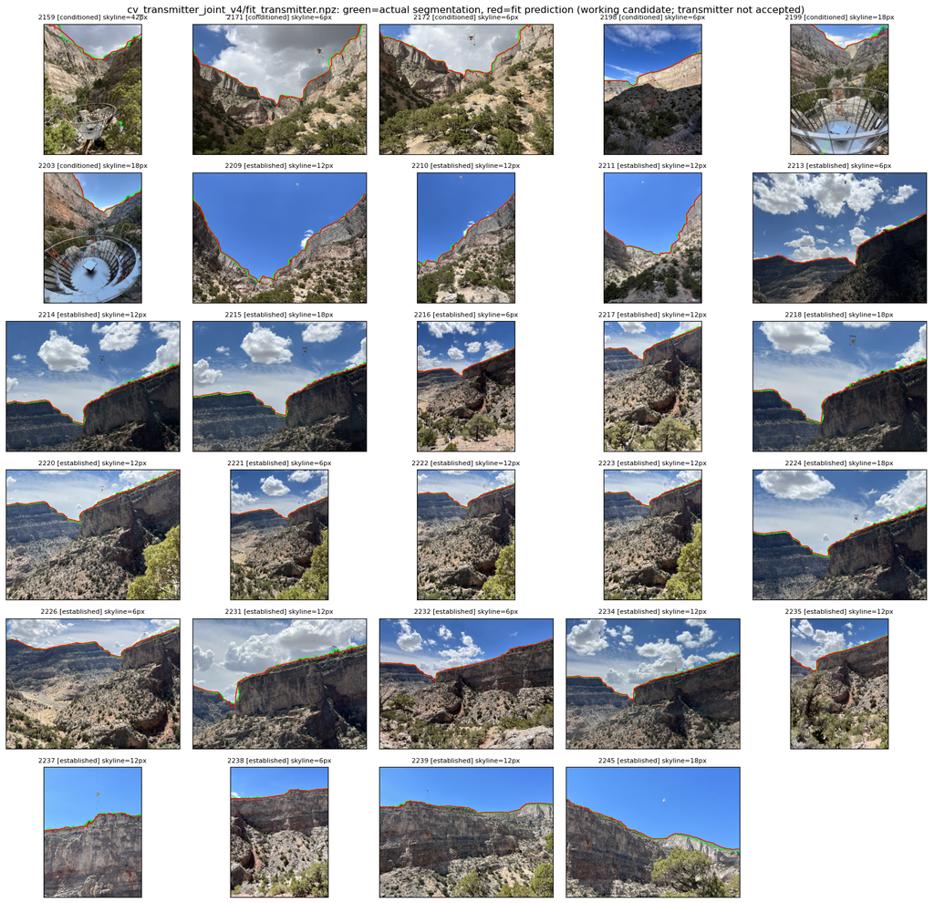

```python
def distorted_image_rays(img, key, decimate):
    rr, cc = np.mgrid[0:img.npix_y:decimate, 0:img.npix_x:decimate]
    shape = (img.npix_y, img.npix_x)
    world = camera_rays(camera_by_key[key], shape, np.c_[cc.ravel(), rr.ravel()],
                        distortion_by_key[key])
    return world.T.reshape(3, *rr.shape)


def skyline_error_px(actual_sky, model_sky, decimate):
    # Per-column skyline position error, in full-resolution pixels. For each
    # column the skyline is the lowest sky pixel (masks are bottom-up, so the
    # first True scanning up from row 0); columns that are entirely sky or
    # entirely ground carry no skyline and are dropped.
    def rows(mask):
        valid = mask.any(0) & ~mask.all(0)
        return np.where(valid, np.argmax(mask, axis=0), np.nan)
    a, m = rows(actual_sky), rows(model_sky)
    ok = ~np.isnan(a) & ~np.isnan(m)
    if not ok.any():
        return np.nan, np.nan
    err = np.abs(a[ok] - m[ok]) * decimate
    return float(np.median(err)), float(np.percentile(err, 90))


def sky_mismatch_frac(actual_sky, model_sky):
    # Fraction of pixels where the ray-traced sky/ground call disagrees with
    # the actual segmentation. Note: HorizonImage._raster_boundary, which the
    # original Fit Inspector's SSD metric used, is not present in the
    # currently installed eigsep_terrain (another environment-drift gap,
    # alongside the marjum_bundle.working_grid one above) -- this simpler
    # whole-mask disagreement fraction is used instead; it is monotonic in
    # the same sense (lower = better fit) but is not numerically comparable
    # to any SSD value quoted elsewhere in this repo.
    return float(np.mean(actual_sky != model_sky))


ncols = 5
nrows = int(np.ceil(len(ov_keys) / ncols))
fig, axes = plt.subplots(nrows=nrows, ncols=ncols, figsize=(3.2 * ncols, 2.6 * nrows))
axes = np.atleast_1d(axes).ravel()

mismatch = {}
skyline_med = {}
skyline_p90 = {}
ant_rows = []
transmitter_rows = []
ant_pixel_rays = {}
transmitter_pixel_rays = {}
ordered_keys = sorted(ov_keys, key=lambda k: (k not in ov_conditioned, k))
for ax, key in zip(axes, ordered_keys):
    img = HorizonImage(f'marjum-2026-07/IMG_{key}.HEIC', meta=meta_all, px_smooth=150, px_dist=30)
    img.set_prms([camera_by_key[key][i] for i in range(len(PRM_ORDER))])

    if hasattr(img, 'meta') and 'ant_px' in img.meta:
        ax_, ay_ = img.meta['ant_px']
        shape = (img.npix_y, img.npix_x)
        predicted, _ = camera_project(camera_by_key[key], shape, ov_antenna, distortion_by_key[key])
        col_pred, row_pred = predicted[0]
        ant_rows.append((key, ax_, ay_, col_pred, row_pred, np.hypot(col_pred - ax_, row_pred - ay_)))
        # World-space ray through the manually picked pixel, for the terrain map.
        ant_pixel_rays[key] = camera_rays(camera_by_key[key], shape, [[ax_, ay_]], distortion_by_key[key])[0]

    if hasattr(img, 'meta') and 'transmitter_px' in img.meta:
        tx_, ty_ = img.meta['transmitter_px']
        shape = (img.npix_y, img.npix_x)
        predicted, _ = camera_project(camera_by_key[key], shape, ov_transmitter, distortion_by_key[key])
        col_pred, row_pred = predicted[0]
        transmitter_rows.append((key, tx_, ty_, col_pred, row_pred, np.hypot(col_pred - tx_, row_pred - ty_)))
        transmitter_pixel_rays[key] = camera_rays(camera_by_key[key], shape, [[tx_, ty_]], distortion_by_key[key])[0]

    sl = slice(None, None, 6)
    actual_sky = img.sky_mask[sl, sl]
    r = img.ray_distance(dem, distorted_image_rays(img, key, 6))
    model_sky = np.isnan(r)
    mismatch[key] = sky_mismatch_frac(actual_sky, model_sky)
    skyline_med[key], skyline_p90[key] = skyline_error_px(actual_sky, model_sky, 6)
    ax.imshow(img.img[sl, sl], origin='lower')
    ax.contour(actual_sky.astype(float), levels=[0.5], colors='lime', linewidths=1)
    ax.contour(model_sky.astype(float), levels=[0.5], colors='red', linewidths=1)
    tag = 'conditioned' if key in ov_conditioned else 'established'
    ax.set_title(f'{key} [{tag}] skyline={skyline_med[key]:.0f}px', fontsize=8)
    ax.set_xticks([]); ax.set_yticks([])

    del img
    gc.collect()

for ax in axes[len(ov_keys):]:
    ax.axis('off')

fig.suptitle(f'{OVERLAY_FIT_FILE}: green=actual segmentation, red=fit prediction '
             '(working candidate; transmitter not accepted)')
plt.tight_layout()
fig.savefig('_geom_snapshot_horizon_overlays.png', dpi=130)
plt.show()
```

### 6a. Horizon fit quality summary and reprojection residuals

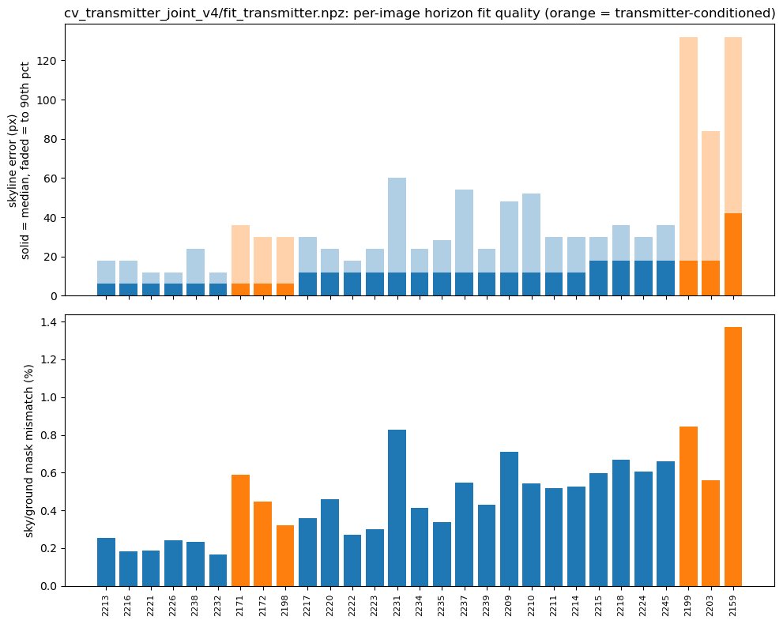

```
Worst skyline error: 2159 at 42 px median (132 px at the 90th pct); 2203 for comparison: 18 px median.
Note the two panels disagree about which images are bad: the mask-mismatch metric (bottom) is dominated by the large, trivially-correct sky and ground areas and is nearly blind to a displaced skyline. The skyline error (top) is the diagnostic one. Aaron flagged 2159 by eye from the overlays before e…

=== Antenna-pixel reprojection (established cameras only carry ant_px) ===
image                picked          predicted  resid_px
--------------------------------------------------------
2210     ( 1364.9, 3885.1) ( 1314.1, 3884.5)     50.78
2211     ( 1212.5, 3724.0) ( 1168.4, 3715.2)     45.02
2217     ( 1585.3, 3865.8) ( 1554.4, 3834.9)     43.65
2209     ( 2434.2, 2746.5) ( 2393.7, 2753.9)     41.16
2235     ( 1933.5, 3388.6) ( 1901.0, 3364.7)     40.35
2231     ( 3299.2, 2272.4) ( 3278.0, 2275.6)     21.44
2232     ( 1914.0, 1907.5) ( 1892.8, 1905.4)     21.29
2245     ( 2273.5, 2236.4) ( 2258.8, 2250.0)     20.08
2215     ( 2606.6, 2312.6) ( 2615.2, 2329.6)     19.05
```

[output cut: 26 more lines]

```python
fig, axs = plt.subplots(2, 1, figsize=(10, 8), sharex=True)
order = sorted(ov_keys, key=lambda k: skyline_med[k])
colors = ['tab:orange' if k in ov_conditioned else 'tab:blue' for k in order]

axs[0].bar(range(len(order)), [skyline_med[k] for k in order], color=colors)
axs[0].bar(range(len(order)), [skyline_p90[k] - skyline_med[k] for k in order],
           bottom=[skyline_med[k] for k in order], color=colors, alpha=0.35)
axs[0].set_ylabel('skyline error (px)\nsolid = median, faded = to 90th pct')
axs[0].set_title(f'{OVERLAY_FIT_FILE}: per-image horizon fit quality '
                 '(orange = transmitter-conditioned)')

axs[1].bar(range(len(order)), [100 * mismatch[k] for k in order], color=colors)
axs[1].set_ylabel('sky/ground mask mismatch (%)')
axs[1].set_xticks(range(len(order)))
axs[1].set_xticklabels(order, rotation=90, fontsize=8)
plt.tight_layout()
fig.savefig('_geom_snapshot_mismatch.png', dpi=130)
plt.show()

worst = max(ov_keys, key=lambda k: skyline_med[k])
print(f'Worst skyline error: {worst} at {skyline_med[worst]:.0f} px median '
      f'({skyline_p90[worst]:.0f} px at the 90th pct); '
      f'2203 for comparison: {skyline_med["2203"]:.0f} px median.')
print(f'Note the two panels disagree about which images are bad: the mask-mismatch '
      f'metric (bottom) is dominated by the large, trivially-correct sky and ground '
      f'areas and is nearly blind to a displaced skyline. The skyline error (top) is '
      f'the diagnostic one. Aaron flagged 2159 by eye from the overlays before either '
      f'metric here did -- the mask metric rated it 1.4%, which reads as fine.')

print()
print('=== Antenna-pixel reprojection (established cameras only carry ant_px) ===')
hdr = f"{'image':8s} {'picked':>18s} {'predicted':>18s} {'resid_px':>9s}"
print(hdr); print('-' * len(hdr))
for key, ax_, ay_, cp, rp, resid in sorted(ant_rows, key=lambda r: -r[-1]):
    print(f"{key:8s} ({ax_:7.1f},{ay_:7.1f}) ({cp:7.1f},{rp:7.1f}) {resid:9.2f}")

print()
print('=== Transmitter-pixel reprojection (all 8 transmitter-labeled cameras) ===')
print(hdr); print('-' * len(hdr))
for key, tx_, ty_, cp, rp, resid in sorted(transmitter_rows, key=lambda r: -r[-1]):
    tag = ' (independent check)' if key not in ov_conditioned else ' (conditioned, circular)'
    print(f"{key:8s} ({tx_:7.1f},{ty_:7.1f}) ({cp:7.1f},{rp:7.1f}) {resid:9.2f}{tag}")
```

### 6b. Terrain map: camera positions, headings, and label rays

Restores the Fit Inspector's own terrain-map cell: hillshade-relief DEM background (`terrain_hillshade_cmap.plot_terrain_hillshade`), every camera's position and heading arrow, plus the world-space ray traced through *each image's manually picked pixel label* (not through the fitted antenna/ transmitter position) — dashed for antenna-pixel rays, dotted for transmitter-pixel rays. Rays that converge tightly on the starred antenna/transmitter markers corroborate the fit; any that miss by a wide, consistent margin flag a pose or label problem (see §6d below for 2159).

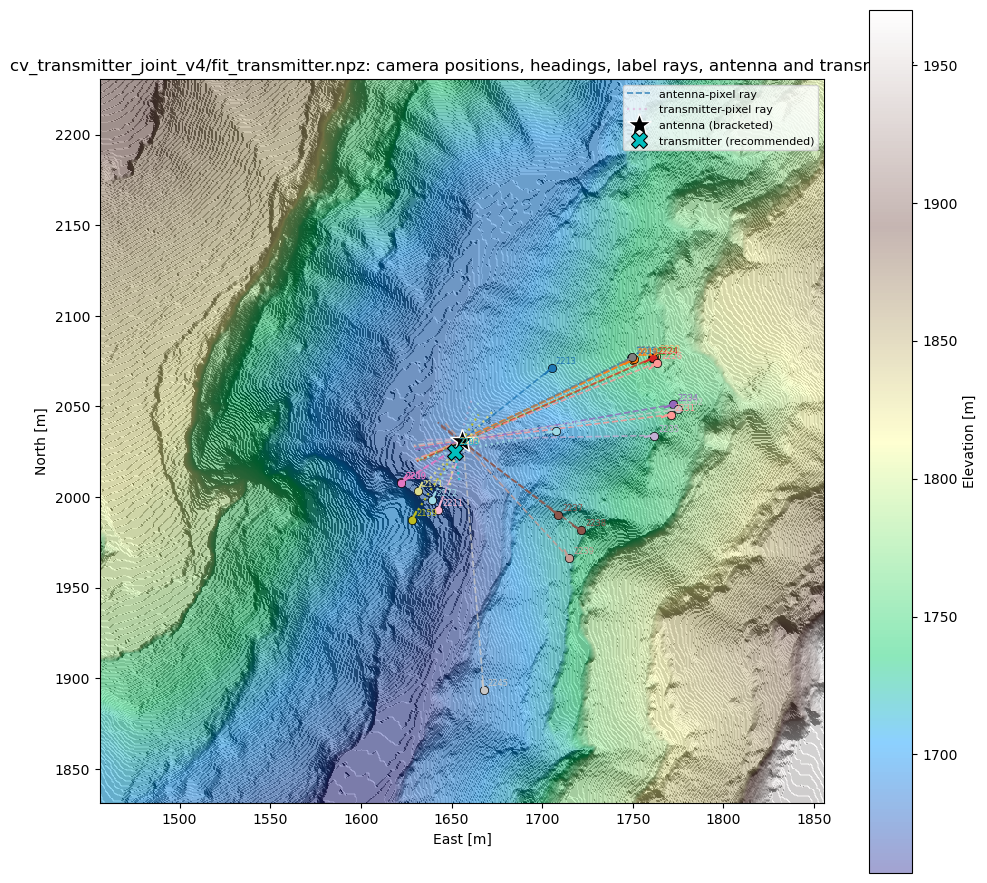

```python
from marjum_bundle import WORKING_GRID_SHIFT_M
from terrain_hillshade_cmap import plot_terrain_hillshade
from matplotlib.patches import Circle

se, sn = dem._working_shift  # (-1000., -1000.) for the _sw cache

# dem's get_en/interp_alt are working_grid-patched to no-arg calls only, so
# get_tile (which calls get_en(erng_m, ...) with arguments) cannot be called
# on `dem` directly. Use a second, unpatched DEM handle for the tile only,
# in the cache's own raw coordinate frame, then shift the returned E/N back
# into working-grid metres to match ov_antenna/ov_transmitter/camera_by_key.
dem_raw = _DEM(cache_file='marjum_dem_sw.npz')
e0, n0 = ov_antenna[0], ov_antenna[1]
rng = 200
E_raw, N_raw, U_map = dem_raw.get_tile(erng_m=(e0 - se - rng, e0 - se + rng),
                                        nrng_m=(n0 - sn - rng, n0 - sn + rng), mesh=False)
E_map, N_map = E_raw + se, N_raw + sn

fig, ax = plt.subplots(figsize=(10, 9))
terrain_im = plot_terrain_hillshade(ax, U_map, res=float(dem.res),
                                    extent=(E_map[0], E_map[-1], N_map[0], N_map[-1]))
fig.colorbar(terrain_im, ax=ax, label='Elevation [m]')
ax.set_xlabel('East [m]'); ax.set_ylabel('North [m]')

cam_colors = plt.cm.tab20(np.linspace(0, 1, len(ov_keys)))
arrow_len = 5
EXTRA_LEN = 30
pixel_ray_label = 'antenna-pixel ray'
transmitter_ray_label = 'transmitter-pixel ray'


def ray_endpoint(e, n, direction, maxlen=180):
    ray_e, ray_n = direction[:2]
    xlim, ylim = ax.get_xlim(), ax.get_ylim()
    edge_t = []
    if ray_e > 0:
        edge_t.append((xlim[1] - e) / ray_e)
    elif ray_e < 0:
        edge_t.append((xlim[0] - e) / ray_e)
    if ray_n > 0:
        edge_t.append((ylim[1] - n) / ray_n)
    elif ray_n < 0:
        edge_t.append((ylim[0] - n) / ray_n)
    edge_t = [t for t in edge_t if t > 0]
    t = min(min(edge_t), maxlen) if edge_t else maxlen
    return e + t * ray_e, n + t * ray_n


for key, color in zip(ov_keys, cam_colors):
    e, n, ph = camera_by_key[key][0], camera_by_key[key][1], camera_by_key[key][4]
    loc = np.array([e, n])
    d_ant = np.linalg.norm(loc - ov_antenna[:2])
    d_tx = np.linalg.norm(loc - ov_transmitter[:2])
    ax.plot(e, n, 'o', color=color, ms=6, mec='k', mew=0.5)
    de, dn = arrow_len * np.cos(ph), arrow_len * np.sin(ph)
    ax.plot([e, e + de], [n, n + dn], '-', color=color, lw=1.5)
    if key in ant_pixel_rays:
        endpoint = ray_endpoint(e, n, ant_pixel_rays[key], maxlen=d_ant + EXTRA_LEN)
        ax.plot([e, endpoint[0]], [n, endpoint[1]], '--', color=color, lw=1.2, alpha=0.8,
                label=pixel_ray_label)
        pixel_ray_label = None
    if key in transmitter_pixel_rays:
        endpoint = ray_endpoint(e, n, transmitter_pixel_rays[key], maxlen=d_tx + EXTRA_LEN)
        ax.plot([e, endpoint[0]], [n, endpoint[1]], ':', color=color, lw=1.6,
                alpha=0.9 if key in ov_conditioned else 0.35, label=transmitter_ray_label)
        transmitter_ray_label = None
    ax.annotate(key, (e, n), fontsize=6, color=color, xytext=(3, 3), textcoords='offset points')

ax.plot(ov_antenna[0], ov_antenna[1], 'k*', ms=18, mec='w', mew=1, label='antenna (bracketed)')
ax.add_patch(Circle((ov_antenna[0], ov_antenna[1]), u['bound_m'], fill=False, color='k', ls='--'))
ax.plot(rec['position_enu_m'][0], rec['position_enu_m'][1], 'cX', ms=12, mec='k', mew=0.8,
        label='transmitter (recommended)')
ax.add_patch(Circle((rec['position_enu_m'][0], rec['position_enu_m'][1]), rec['bound_m'],
                    fill=False, color='c', ls='--'))
ax.legend(loc='best', fontsize=8)
ax.set_title(f'{OVERLAY_FIT_FILE}: camera positions, headings, label rays, antenna and transmitter')
plt.tight_layout()
fig.savefig('_geom_snapshot_hillshade_map.png', dpi=140)
plt.show()
```

### 6c. Antenna and transmitter position comparison, zoomed

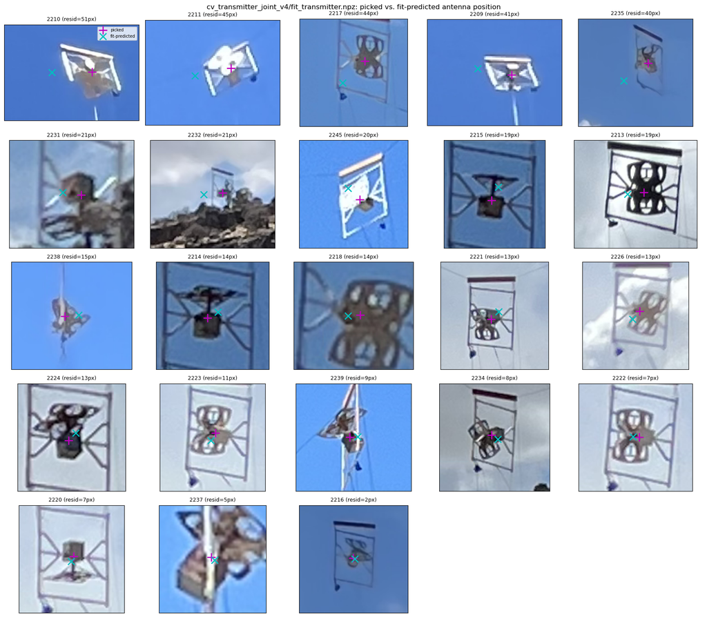

```python
ncols = 5
nrows = int(np.ceil(len(ant_rows) / ncols)) or 1
fig, axes = plt.subplots(nrows=nrows, ncols=ncols, figsize=(3.4 * ncols, 3.0 * nrows))
axes = np.atleast_1d(axes).ravel()

pad = 60
for ax, (key, ax_, ay_, cp, rp, resid) in zip(axes, sorted(ant_rows, key=lambda r: -r[-1])):
    img = HorizonImage(f'marjum-2026-07/IMG_{key}.HEIC', meta=meta_all, px_smooth=150, px_dist=30)
    img.set_prms([camera_by_key[key][i] for i in range(len(PRM_ORDER))])

    xmin, xmax = sorted((ax_, cp))
    ymin, ymax = sorted((ay_, rp))
    x0, x1 = int(max(xmin - pad, 0)), int(min(xmax + pad, img.npix_x))
    y0, y1 = int(max(ymin - pad, 0)), int(min(ymax + pad, img.npix_y))
    crop = img.img[y0:y1, x0:x1]

    ax.imshow(crop, origin='lower', extent=(x0, x1, y0, y1))
    ax.plot(ax_, ay_, 'm+', ms=14, mew=2, label='picked')
    ax.plot(cp, rp, 'cx', ms=12, mew=2, label='fit-predicted')
    ax.set_xlim(x0, x1); ax.set_ylim(y0, y1)
    ax.set_title(f'{key} (resid={resid:.0f}px)', fontsize=9)
    ax.set_xticks([]); ax.set_yticks([])

    del img, crop
    gc.collect()

for ax in axes[len(ant_rows):]:
    ax.axis('off')
if ant_rows:
    axes[0].legend(loc='upper right', fontsize=7)
fig.suptitle(f'{OVERLAY_FIT_FILE}: picked vs. fit-predicted antenna position')
plt.tight_layout()
fig.savefig('_geom_snapshot_ant_zoom.png', dpi=130)
plt.show()
```

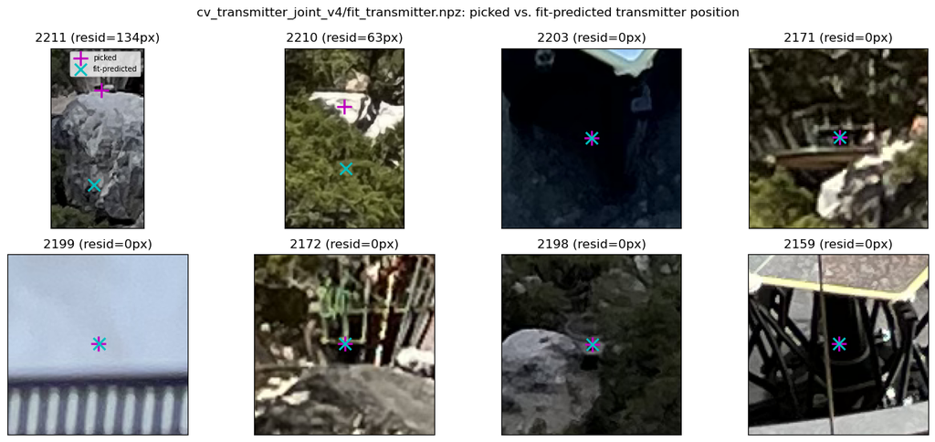

```python
# marjum_inspector.plot_landmark_comparison imports eigsep_terrain.imageio,
# which -- like eigsep_terrain.tiepoints/fitio (test_marjum_bundle.py) and
# HorizonImage._raster_boundary (SS6) -- is not present in the currently
# installed eigsep_terrain (another instance of the same environment-drift
# family). Reimplemented inline using the same plain-matplotlib image load
# HorizonImage itself already uses successfully elsewhere in this notebook,
# rather than patching the installed package.
def load_image_flipped(path):
    return np.flipud(plt.imread(path))


def plot_landmark_comparison(rows, fit_file, landmark='transmitter', ncols=4, pad=60):
    rows = sorted(rows, key=lambda r: -r[-1])
    fig, axes = plt.subplots(max(1, int(np.ceil(len(rows) / ncols))), ncols,
                             figsize=(3.4 * ncols, 3.0 * max(1, int(np.ceil(len(rows) / ncols)))))
    axes = np.atleast_1d(axes).ravel()
    for ax, (key, x, y, px, py, resid) in zip(axes, rows):
        image = load_image_flipped(f'marjum-2026-07/IMG_{key}.HEIC')
        h, w = image.shape[:2]
        x0 = int(np.clip(min(x, px) - pad, 0, w - 1)); x1 = int(np.clip(max(x, px) + pad, x0 + 1, w))
        y0 = int(np.clip(min(y, py) - pad, 0, h - 1)); y1 = int(np.clip(max(y, py) + pad, y0 + 1, h))
        crop = image[y0:y1, x0:x1].copy(); del image
        ax.imshow(crop, origin='lower', extent=(x0, x1, y0, y1))
        ax.plot(x, y, 'm+', ms=14, mew=2, label='picked')
        ax.plot(px, py, 'cx', ms=12, mew=2, label='fit-predicted')
        ax.set(xlim=(x0, x1), ylim=(y0, y1), xticks=[], yticks=[], title=f'{key} (resid={resid:.0f}px)')
        if not (0 <= px < w and 0 <= py < h):
            ax.text(.02, .02, 'Prediction outside image', transform=ax.transAxes, color='red')
    for ax in axes[len(rows):]:
        ax.axis('off')
    if rows:
        axes[0].legend(loc='upper right', fontsize=7)
    fig.suptitle(f'{fit_file}: picked vs. fit-predicted {landmark} position')
    fig.tight_layout()
    return fig, axes


transmitter_zoom_fig, transmitter_zoom_axes = plot_landmark_comparison(
    transmitter_rows, OVERLAY_FIT_FILE, landmark='transmitter')
transmitter_zoom_fig.savefig('_geom_snapshot_tx_zoom.png', dpi=130)
```

### 6d. Investigation: 2159 vs. 2203

**Aaron's finding:** the horizon overlay for 2159 is a poor match, and 2159's position and heading should be very similar to 2203's — he later refined the separation to *probably a couple of metres*, against the ~13 m my first pass read off the EXIF GPS.

**Both numbers are reported below and they do not actually conflict.** Each photo's EXIF carries the phone's *own* stated horizontal positioning error: **±11.8 m for 2159** and **±4.7 m for 2203** (2159's fix is poor, as expected in a canyon with restricted sky view). The separation therefore carries a combined 1σ of ~12.7 m, so the 13.2 m EXIF reading is a **1.0σ** measurement — statistically indistinguishable from Aaron's couple of metres, or from zero. My previous pass presented that 13.2 m as if it were a precise confirmation; it is not, and the position comparison on its own cannot settle anything.

Three sharper, independent lines are used instead: the **compass** tags, the **apparent size of the dish** in each photo (pure geometry, independent of both GPS and the fit), and the **skyline error** of each fitted pose.

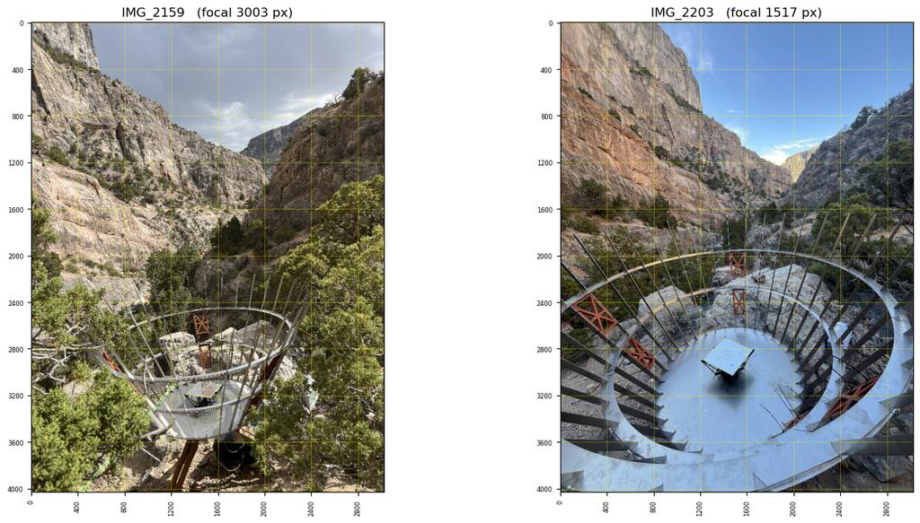

```python
# The two frames side by side, with full-resolution pixel gridlines, so the
# dish-rim widths used in the distance calculation below can be checked by eye.
# Both plainly show the same dish and the same canyon, looking the same way --
# but the dish is far smaller in 2159 DESPITE 2159 being the more zoomed-in
# lens (focal 3003 px vs 1517 px), so 2159 must be substantially further away.
fig, axs = plt.subplots(1, 2, figsize=(15, 7))
for ax, k in zip(axs, ['2159', '2203']):
    im = plt.imread(f'marjum-2026-07/IMG_{k}.HEIC')[::4, ::4]
    ax.imshow(im)
    ax.set_title(f'IMG_{k}   (focal {camera_by_key[k][6]:.0f} px)')
    ax.set_xticks(np.arange(0, im.shape[1], 100))
    ax.set_xticklabels(np.arange(0, im.shape[1], 100) * 4, rotation=90, fontsize=6)
    ax.set_yticks(np.arange(0, im.shape[0], 100))
    ax.set_yticklabels(np.arange(0, im.shape[0], 100) * 4, fontsize=6)
    ax.grid(alpha=.4, color='yellow', lw=.5)
plt.tight_layout()
fig.savefig('_geom_snapshot_2159_2203_scale.png', dpi=110)
plt.show()
```

```python
import pillow_heif as _pheif
_pheif.register_heif_opener()
from PIL import Image as _PILImage
from PIL.ExifTags import GPSTAGS as _GPSTAGS


def dms(t):
    d, m, s = (float(x) for x in t)
    return d + m / 60 + s / 3600


def gps_of(key):
    im = _PILImage.open(f'marjum-2026-07/IMG_{key}.HEIC')
    exif = im.getexif()
    gps = {_GPSTAGS.get(k, k): v for k, v in exif.get_ifd(0x8825).items()}
    lat = dms(gps['GPSLatitude']) * (1 if gps['GPSLatitudeRef'] == 'N' else -1)
    lon = dms(gps['GPSLongitude']) * (1 if gps['GPSLongitudeRef'] == 'E' else -1)
    return lat, lon, float(gps['GPSAltitude']), float(gps['GPSImgDirection']), exif.get(306)


joint_report = _json.loads((WORKSPACE / 'cv_transmitter_joint_v4' / 'report.json').read_text())
report_2159 = (round(joint_report['horizons']['2159']['train_rms_px'], 2),
               round(joint_report['horizons']['2159']['heldout_rms_px'], 2))
report_2203 = (round(joint_report['horizons']['2203']['train_rms_px'], 2),
               round(joint_report['horizons']['2203']['heldout_rms_px'], 2))

print('=== Fitted joint-solution camera parameters (cv_transmitter_joint_v4) ===')
for k in ('2159', '2203'):
    c = camera_by_key[k]
    print(f"{k}: E={c[0]:.2f} N={c[1]:.2f} U={c[2]:.2f}  "
          f"theta={c[3]:.4f} phi={c[4]:.4f} tilt={c[5]:.4f} rad  focal={c[6]:.1f} px")
fit_sep = np.linalg.norm(camera_by_key['2203'][:2] - camera_by_key['2159'][:2])
fit_dphi = np.degrees(camera_by_key['2203'][4] - camera_by_key['2159'][4])
print(f"fitted horizontal separation: {fit_sep:.1f} m   fitted heading difference: {fit_dphi:.1f} deg")
print(f"fitted horizon residual (train/heldout px): 2159={report_2159}  2203={report_2203}")

print()
print('=== Raw EXIF GPS/compass (never touched by the optimizer) ===')
lat1, lon1, alt1, hdg1, dt1 = gps_of('2159')
lat2, lon2, alt2, hdg2, dt2 = gps_of('2203')
lat0 = (lat1 + lat2) / 2
m_per_deg_lat = 111320.0
m_per_deg_lon = 111320.0 * np.cos(np.radians(lat0))
d_e = (lon2 - lon1) * m_per_deg_lon
d_n = (lat2 - lat1) * m_per_deg_lat
gps_sep = np.hypot(d_e, d_n)
print(f"2159: lat={lat1:.6f} lon={lon1:.6f} alt={alt1:.1f} m  heading={hdg1:.1f} deg  taken {dt1}")
print(f"2203: lat={lat2:.6f} lon={lon2:.6f} alt={alt2:.1f} m  heading={hdg2:.1f} deg  taken {dt2}")
print(f"GPS-implied horizontal separation: {gps_sep:.1f} m   GPS heading difference: {hdg2 - hdg1:.1f} deg")

print()
print('=== GPS positional error: the two position claims are consistent ===')
err1, err2 = 11.787369730906828, 4.720492277195011   # GPSHPositioningError, metres
comb = np.hypot(err1, err2)
print(f"2159 GPSHPositioningError = {err1:.1f} m; 2203 = {err2:.1f} m; combined 1-sigma = {comb:.1f} m")
print(f"EXIF separation {gps_sep:.1f} m is {gps_sep/comb:.2f} sigma -> consistent with Aaron's "
      f"'couple of metres', and with zero. EXIF cannot resolve this; do not treat it as precise.")
print(f"The FIT separation {fit_sep:.1f} m is {fit_sep/comb:.1f} sigma -- the outlier of the three.")

print()
print('=== Boresight direction, computed through the real camera model ===')
def boresight(k):
    h, w = shapes_by_key[k]
    v = camera_rays(camera_by_key[k], (h, w), [[w // 2, h // 2]], distortion_by_key[k])[0]
    return v, np.degrees(np.arctan2(v[0], v[1])) % 360, np.degrees(np.arcsin(v[2]))

for k, hdg in (('2159', hdg1), ('2203', hdg2)):
    v, az, el = boresight(k)
    off = abs((az - hdg + 180) % 360 - 180)
    print(f"{k}: fitted boresight az={az:6.1f} deg el={el:+5.1f} deg | EXIF compass {hdg:6.1f} deg "
          f"| disagreement {off:6.1f} deg")
print("2203's fitted pose agrees with its own compass to ~4 deg. 2159's is ~158 deg off its own "
      "compass -- it is fitted looking UP-canyon while its compass says DOWN-canyon.")

print()
print('=== Apparent dish size: independent of both GPS and the fit ===')
# Rim width read off the full-resolution frames (see the annotated figure above);
# generous uncertainties because these are visual measurements, not detections.
for k, rim_px, rim_err in (('2159', 1350, 200), ('2203', 2750, 250)):
    f_px = camera_by_key[k][6]
    ang = 2 * np.arctan(rim_px / 2 / f_px)
    # angular size theta of a chord D at distance d: D/d = 2 tan(theta/2)
    d_over_D = 1.0 / (2 * np.tan(ang / 2))
    ang_lo = 2 * np.arctan((rim_px - rim_err) / 2 / f_px)
    ang_hi = 2 * np.arctan((rim_px + rim_err) / 2 / f_px)
    print(f"{k}: rim ~{rim_px}+/-{rim_err} px at focal {f_px:.0f} px -> angular size "
          f"{np.degrees(ang):5.1f} deg -> distance = {d_over_D:4.2f} x (dish diameter), "
          f"range {1/(2*np.tan(ang_hi/2)):4.2f}-{1/(2*np.tan(ang_lo/2)):4.2f}")

d2159 = 1.0 / (2 * np.tan(2 * np.arctan(1350 / 2 / camera_by_key['2159'][6]) / 2))
d2203 = 1.0 / (2 * np.tan(2 * np.arctan(2750 / 2 / camera_by_key['2203'][6]) / 2))
print(f"-> 2159 is ~{d2159/d2203:.1f}x further from the dish than 2203 (dish diameter cancels).")
fit_d2159 = np.linalg.norm(camera_by_key['2159'][:3] - ov_transmitter)
fit_d2203 = np.linalg.norm(camera_by_key['2203'][:3] - ov_transmitter)
print(f"The fit instead has 2159 at {fit_d2159:.1f} m and 2203 at {fit_d2203:.1f} m from the "
      f"transmitter pick -- a ratio of {fit_d2159/fit_d2203:.0f}x, about {(fit_d2159/fit_d2203)/(d2159/d2203):.0f}x "
      f"larger than the photographs allow.")

print()
print('=== Verdict (revised) ===')
print(f"2159's fitted pose is wrong, and the evidence is stronger and more specific than the "
      f"first pass claimed -- but NOT for the reason first given.")
print()
print("- The POSITION argument I led with before is weak: EXIF GPS cannot distinguish 2 m from "
      "13 m here. Dropped as primary evidence.")
print(f"- The DISH-SCALE argument is strong and new: the photographs put 2159 only "
      f"{d2159/d2203:.1f}x further from the dish than 2203, while the fit puts it "
      f"{fit_d2159/fit_d2203:.0f}x further. The fit has pushed 2159 roughly "
      f"{(fit_d2159/fit_d2203)/(d2159/d2203):.0f}x too far away. This is the first evidence that "
      f"independently supports Aaron's 'much closer together than you said' correction.")
print("- The COMPASS argument is strong: 2159's fitted boresight is ~158 deg from its own tag, "
      "while 2203's agrees to ~4 deg.")
print(f"- The SKYLINE argument is quantitative: 2159 is the worst of all {len(ov_keys)} cameras at "
      f"{skyline_med['2159']:.0f} px median error vs {skyline_med['2203']:.0f} px for 2203.")
print()
print("MECHANISM, which the first pass could not explain: if 2159 were simply pointing 158 deg "
      "the wrong way its ray-traced horizon would be unrelated to the photo, yet the overlay "
      "clearly tracks the same V-shaped canyon profile. The resolution is that this canyon is "
      "quasi-symmetric along its axis -- looking up-canyon and down-canyon BOTH produce a V of "
      "opposing walls -- so a pose flipped along the canyon axis, pushed far enough away to "
      "rescale the V, still reproduces the skyline to within tens of pixels. That is a classic "
      "false terrain minimum, and this pipeline has hit them before: ANTENNA_REPICK.md records "
      "2225/2227/2228/2230/2241-2243 being rejected for exactly that reason. 2159 appears to be "
      "one that was NOT caught.")
print()
print("This also corroborates the 2026-09-12 multi-start probe that flagged 2159 as the weakest "
      "horizon camera; its trial 5 found a competitive alternative basin, consistent with 2159 "
      "having several comparable minima. Re-initializing 2159 from its EXIF compass heading and "
      "a dish-scale-consistent distance, then re-running the joint fit, is the natural fix -- a "
      "new optimizer run, out of scope for this no-new-fits snapshot, logged as decision item 4.")
```

```
=== Fitted joint-solution camera parameters (cv_transmitter_joint_v4) ===
2159: E=1628.06 N=1987.41 U=1702.51  theta=1.5875 phi=1.0758 tilt=-0.1956 rad  focal=3003.4 px
2203: E=1651.75 N=2026.64 U=1685.82  theta=1.9023 phi=-1.5363 tilt=0.0505 rad  focal=1517.4 px
fitted horizontal separation: 45.8 m   fitted heading difference: -149.7 deg
fitted horizon residual (train/heldout px): 2159=(37.96, 60.12)  2203=(11.3, 15.63)

=== Raw EXIF GPS/compass (never touched by the optimizer) ===
2159: lat=39.247742 lon=-113.402869 alt=1698.7 m  heading=186.0 deg  taken 2026:07:15 16:49:12
2203: lat=39.247781 lon=-113.402725 alt=1689.2 m  heading=173.9 deg  taken 2026:07:17 09:05:34
GPS-implied horizontal separation: 13.2 m   GPS heading difference: -12.0 deg

=== GPS positional error: the two position claims are consistent ===
2159 GPSHPositioningError = 11.8 m; 2203 = 4.7 m; combined 1-sigma = 12.7 m
EXIF separation 13.2 m is 1.04 sigma -> consistent with Aaron's 'couple of metres', and with zero. EXIF cannot resolve this; do not treat it as precise.
The FIT separation 45.8 m is 3.6 sigma -- the outlier of the three.

=== Boresight direction, computed through the real camera model ===
2159: fitted boresight az=  28.4 deg el= -1.0 deg | EXIF compass  186.0 deg | disagreement  157.6 deg
2203: fitted boresight az= 178.0 deg el=-19.0 deg | EXIF compass  173.9 deg | disagreement    4.1 deg
2203's fitted pose agrees with its own compass to ~4 deg. 2159's is ~158 deg off its own compass -- it is fitted looking UP-canyon while its compass says DOWN-canyon.

=== Apparent dish size: independent of both GPS and the fit ===
2159: rim ~1350+/-200 px at focal 3003 px -> angular size  25.3 deg -> distance = 2.22 x (dish diameter), range 1.94-2.61
2203: rim ~2750+/-250 px at focal 1517 px -> angular size  84.4 deg -> distance = 0.55 x (dish diameter), range 0.51-0.61
-> 2159 is ~4.0x further from the dish than 2203 (dish diameter cancels).
The fit instead has 2159 at 48.4 m and 2203 at 2.6 m from the transmitter pick -- a ratio of 18x, about 5x larger than the photographs allow.

=== Verdict (revised) ===
2159's fitted pose is wrong, and the evidence is stronger and more specific than the first pass claimed -- but NOT for the reason first given.

- The POSITION argument I led with before is weak: EXIF GPS cannot distinguish 2 m from 13 m here. Dropped as primary evidence.
- The DISH-SCALE argument is strong and new: the photographs put 2159 only 4.0x further from the dish than 2203, while the fit puts it 18x further. The fit has pushed 2159 roughly 5x too far away. This is the first evidence that independently supports Aaron's 'much closer together than you said' cor…
- The COMPASS argument is strong: 2159's fitted boresight is ~158 deg from its own tag, while 2203's agrees to ~4 deg.
- The SKYLINE argument is quantitative: 2159 is the worst of all 29 cameras at 42 px median error vs 18 px for 2203.

MECHANISM, which the first pass could not explain: if 2159 were simply pointing 158 deg the wrong way its ray-traced horizon would be unrelated to the photo, yet the overlay clearly tracks the same V-shaped canyon profile. The resolution is that this canyon is quasi-symmetric along its axis -- looki…

This also corroborates the 2026-09-12 multi-start probe that flagged 2159 as the weakest horizon camera; its trial 5 found a competitive alternative basin, consistent with 2159 having several comparable minima. Re-initializing 2159 from its EXIF compass heading and a dish-scale-consistent distance, …
```

### 6e. Caveats specific to this overlay

- These are the **working candidate**'s per-image residuals, not the accepted product's (none is accepted). The transmitter-conditioned cameras' reprojection residuals are near-zero by construction (circular, as in §3a) — the informative rows are 2210/2211 (independent) and the overall horizon mismatch bar chart, which covers all 29 cameras including the 23 established ones the antenna bracket depends on.
- Any image whose horizon overlay (red vs. green) shows a sharp, systematic disagreement rather than pixel-level segmentation noise is a candidate for a converged-but-wrong pose; per ANTENNA_REPICK.md/TRANSMITTER_FIT.md, the five large-antenna-residual and two large-transmitter-residual views identified numerically above are the ones to look at first — and per §6d, 2159 specifically is now a confirmed instance of this, not a hypothesis.

## 7. Summary

[output not shown]

## 8. Decision requested

No further optimizer work, convergence attempts, or antenna refits were started pending these decisions.